# ML_Assignment_HAR

Izma

17 January 2020

The report aims to present analysis on the best approach to determine whether a person is doing an exercise correctly by using readings from wearable accelerometers, put on either the belt, arm, forearm or the dumbbell of the participants from the Human Activity Recognition project (HAR). There are 5 possible classes that each exercise can be classified into: A) exactly according to the specification; B) throwing the elbows to the front; C) lifting the dumbbell only halfway; D) lowering the dumbbell only halfway; and E) throwing the hips to the front.

Please see the below link for more details on the HAR project: http://web.archive.org/web/20161224072740/http:/groupware.les.inf.puc-rio.br/har

## Data cleaning, preprocessing and partitioning

Prior to any model application data needs to be cleaned and prepared, ensuring the model is based on variables that contain the most information. Thus the following procedures were applied: - All irrelevant variables were excluded, e.g. name of the participant, time, date… - All variables with over 95% of missing values were excluded - All variables with near zero variance were excluded

This approach reduced the number of variables from 160 to 53, which are all continuous except for the classification variable (Classe). Remaining variables were pre-processed to account for missing values, by applying the k-nearest neighbours approach, after which data was normalized so all variables implicitly have the same weight.

Finally, data was partitioned into training and test sets (80% and 20% respectively), in order to calculate out-of-sample error before applying the model on the final test data.

## Model Comparison

The next step was to test several models and see which approach best suits the aim of this research: 1) Random Forest (RF) 2) Stochastic Gradient Boosting (GBM) 3) K-Nearest Neighbours (KNN)

The choice of algorithms was based on the Coursera class, but it also includes K-Nearest Neighbours algorithm. Random forest and Stohastic Gradient Boosting algorithms were chosen due to high number of available variables, which are also relatively related to each other (reading from the same device or show a different aspect of a specific movement of the same body part or dumbbell). KNN algorithm was selected due to it being easy to interpret output, lower calculation time and high predictive power.

```r
models_compare <- resamples( list( RF = rf_fit, GBM = gbm_fit, KNN = knn_fit ))
summary(models_compare)
```

```
##
## Call:
## summary.resamples(object = models_compare)
##
## Models: RF, GBM, KNN
## Number of resamples: 50
##
## Accuracy
##          Min.   1st Qu.    Median      Mean   3rd Qu.      Max. NA's
## RF  0.9872652 0.9910835 0.9920395 0.9920059 0.9929146 0.9955414    0
## GBM 0.9525629 0.9561306 0.9594014 0.9596408 0.9624204 0.9691083    0
## KNN 0.9337157 0.9476156 0.9503106 0.9502258 0.9530977 0.9588910    0
##
## Kappa
##          Min.   1st Qu.    Median      Mean   3rd Qu.      Max. NA's
## RF  0.9838914 0.9887210 0.9899292 0.9898870 0.9910355 0.9943602    0
## GBM 0.9399856 0.9444867 0.9486160 0.9489376 0.9524744 0.9609185    0
## KNN 0.9162095 0.9337163 0.9371393 0.9370321 0.9406738 0.9479735    0
```

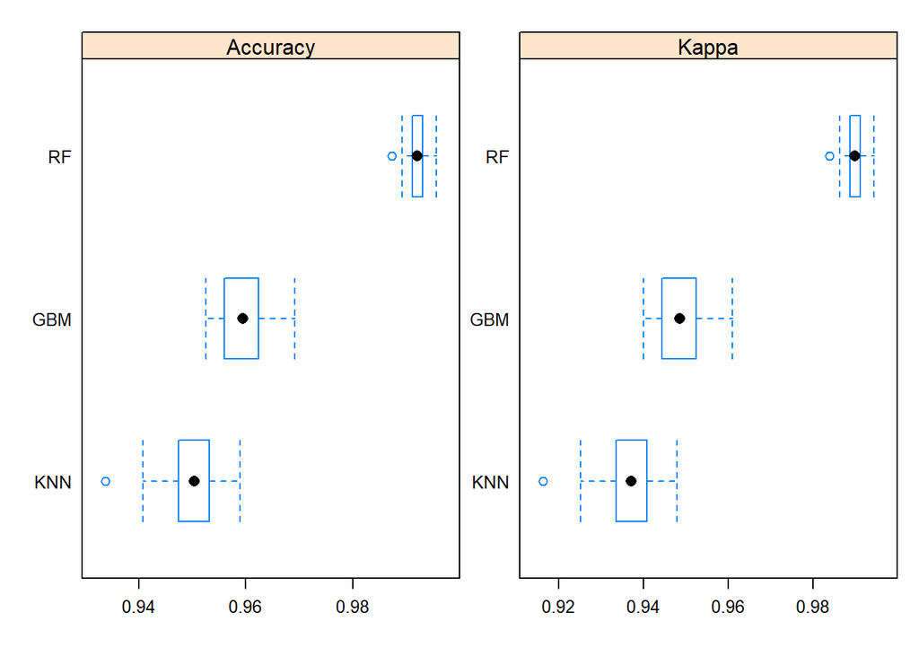

```r
scales      <- list( x = list( relation = "free" ), y = list( relation = "free" ) )
bwplot( models_compare, scales = scales )
```

Therefore, the best model to use for this specific research aim is Random forest. Following analysis will focus on random forest model specifically. As per below confusion matrix, classification was 99% accurate with only a few marginal misclassifications for all classes other than A (exercise performed correctly).

```r
rf_fit
```

```
## Random Forest
##
## 15699 samples
##    52 predictor
##     5 classes: 'A', 'B', 'C', 'D', 'E'
##
## No pre-processing
## Resampling: Cross-Validated (5 fold, repeated 10 times)
## Summary of sample sizes: 12560, 12558, 12558, 12560, 12560, 12558, ...
## Resampling results across tuning parameters:
##
##   mtry  Accuracy   Kappa
##    2    0.9920059  0.9898870
##   27    0.9919358  0.9897985
##   52    0.9852093  0.9812883
##
## Accuracy was used to select the optimal model using the largest value.
## The final value used for the model was mtry = 2.
```

```r
confusionMatrix.train( rf_fit )
```

```
## Cross-Validated (5 fold, repeated 10 times) Confusion Matrix
##
## (entries are percentual average cell counts across resamples)
##
##           Reference
## Prediction    A    B    C    D    E
##          A 28.4  0.1  0.0  0.0  0.0
##          B  0.0 19.1  0.2  0.0  0.0
##          C  0.0  0.1 17.3  0.3  0.0
##          D  0.0  0.0  0.0 16.1  0.0
##          E  0.0  0.0  0.0  0.0 18.3
##
##  Accuracy (average) : 0.992
```

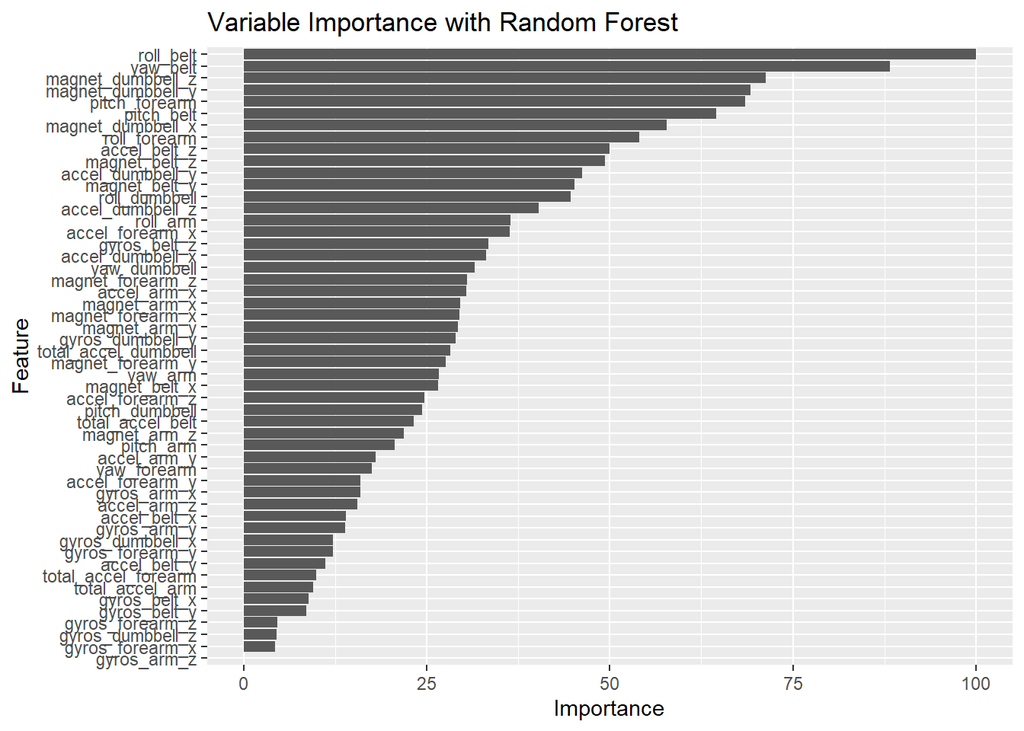

```r
imp_var_rf <- varImp(rf_fit)
g2_rf      <- ggplot(imp_var_rf, colour = "blue")
g2_rf      <- g2_rf + ggtitle( "Variable Importance with Random Forest" )
g2_rf
```

## Out-of-sample testing

Next, out-of-sample analysis was performed on the partitioned test data. The below summary shows results for random forest only, however all three models were checked for out-of-sample error and random forest still showed the best results.

```r
predict_train_rf  <- predict( rf_fit, test_train, type = "raw" )
confusionMatrix( predict_train_rf, test_train$classe )
```

```
## Confusion Matrix and Statistics
##
##           Reference
## Prediction    A    B    C    D    E
##          A 1116    1    0    0    0
##          B    0  757    2    0    0
##          C    0    1  682    9    0
##          D    0    0    0  634    1
##          E    0    0    0    0  720
##
## Overall Statistics
##
##                Accuracy : 0.9964
##                  95% CI : (0.994, 0.998)
##     No Information Rate : 0.2845
##     P-Value [Acc > NIR] : < 2.2e-16
##
##                   Kappa : 0.9955
##  Mcnemar's Test P-Value : NA
##
## Statistics by Class:
##
##                      Class: A Class: B Class: C Class: D Class: E
## Sensitivity            1.0000   0.9974   0.9971   0.9860   0.9986
## Specificity            0.9996   0.9994   0.9969   0.9997   1.0000
## Pos Pred Value         0.9991   0.9974   0.9855   0.9984   1.0000
## Neg Pred Value         1.0000   0.9994   0.9994   0.9973   0.9997
## Prevalence             0.2845   0.1935   0.1744   0.1639   0.1838
## Detection Rate         0.2845   0.1930   0.1738   0.1616   0.1835
## Detection Prevalence   0.2847   0.1935   0.1764   0.1619   0.1835
## Balanced Accuracy      0.9998   0.9984   0.9970   0.9928   0.9993
```

```r
predict_train_gbm <- predict( gbm_fit, test_train, type = "raw" )
## confusionMatrix( predict_train_gbm, test_train$classe )

predict_train_knn <- predict( knn_fit, test_train, type = "raw" )
## confusionMatrix( predict_train_knn, test_train$classe )
```

## Conclusion

As expected Random forest model shows the best performance in terms of accuracy, however it is also the most computationally expensive model. Due to the k-fold cross validation process we applied before choosing the random forest the out-of-sample analysis shows that the model is not overfitting to the training set specifically, since we kept the high level of accuracy here as well.

Other models like gradient boosting can also be used here with relatively high level of accuracy (96%) with smaller computational costs. Thus, the final choice of model should be dependent on both of these aspects costs vs. accuracy.

## Appendix

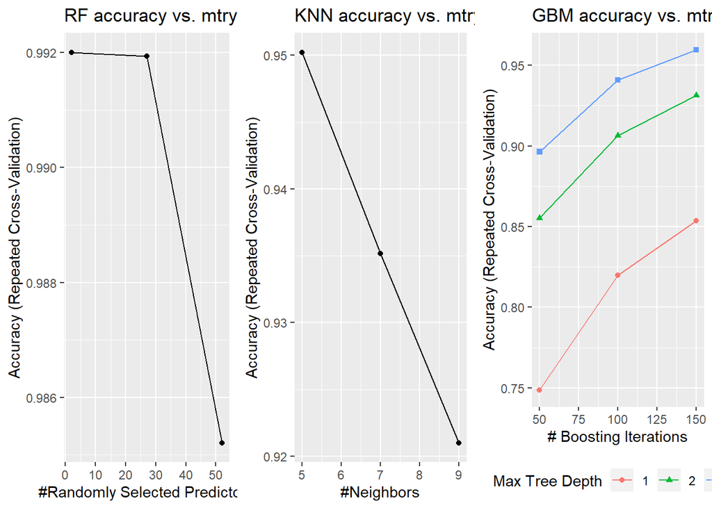

```r
g1_rf      <- ggplot(rf_fit) + ggtitle( "RF accuracy vs. mtry" )
## grid.arrange( g1_rf, g2_rf, ncol=2 )

g1_gbm      <- ggplot( gbm_fit ) + ggtitle( "GBM accuracy vs. mtry" ) + theme( legend.position = "bottom")
## imp_var_gbm <- varImp( gbm_fit)
## g2_gbm      <- ggplot(imp_var_gbm, colour = "blue")
## g2_gbm      <- g2_svm + ggtitle( "Variable Importance with Stohastic Gradient Boost" )
## grid.arrange( g1_gbm, g2_gbm, ncol=2 )

g1_knn      <- ggplot( knn_fit ) + ggtitle( "KNN accuracy vs. mtry" )
imp_var_knn <- varImp( knn_fit )
g2_knn      <- ggplot(imp_var_knn, colour = "blue" )
g2_knn      <- g2_knn + ggtitle( "Variable Importance with K-Nearest Neighbours" )
## grid.arrange( g1_knn, g2_knn, ncol=2 )

grid.arrange( g1_rf, g1_knn, g1_gbm, ncol=3 )
```